# Exploratory Data Analysis

# Introduction

In this practical, we will build upon the topics of the last two weeks, and deepen your understanding of various data wrangling and visualization techniques, using the `tidyverse` functionalities. Additionally, we briefly introduce the concept of missing data and how to visualize relations between the data and missingness.

Don’t forget to open a project file called `03_Exploratory.Rproj` and to create your `.Rmd` or `.R` file to work in.

```r
library(tidyverse)
library(magrittr)
library(mice)
library(DAAG)
```

# The `boys` data

Today, we will work with the `boys` data from the `R` package `mice`, containing information from a sample of 748 boys. Information about this data can be obtained by running the code `?mice::boys`.

When working with a new data set, it is always a good idea to familiarize yourself with the structure of the data.

```r
head(boys)
```

|  | age | hgt | wgt | bmi | hc | gen | phb | tv | reg |
| --- | --- | --- | --- | --- | --- | --- | --- | --- | --- |
| 3 | 0.035 | 50.1 | 3.650 | 14.54 | 33.7 | NA | NA | NA | south |
| 4 | 0.038 | 53.5 | 3.370 | 11.77 | 35.0 | NA | NA | NA | south |
| 18 | 0.057 | 50.0 | 3.140 | 12.56 | 35.2 | NA | NA | NA | south |
| 23 | 0.060 | 54.5 | 4.270 | 14.37 | 36.7 | NA | NA | NA | south |
| 28 | 0.062 | 57.5 | 5.030 | 15.21 | 37.3 | NA | NA | NA | south |
| 36 | 0.068 | 55.5 | 4.655 | 15.11 | 37.0 | NA | NA | NA | south |

```r
tail(boys)
```

|  | age | hgt | wgt | bmi | hc | gen | phb | tv | reg |
| --- | --- | --- | --- | --- | --- | --- | --- | --- | --- |
| 7410 | 20.372 | 188.7 | 59.8 | 16.79 | 55.2 | NA | NA | NA | west |
| 7418 | 20.429 | 181.1 | 67.2 | 20.48 | 56.6 | NA | NA | NA | north |
| 7444 | 20.761 | 189.1 | 88.0 | 24.60 | NA | NA | NA | NA | west |
| 7447 | 20.780 | 193.5 | 75.4 | 20.13 | NA | NA | NA | NA | west |
| 7451 | 20.813 | 189.0 | 78.0 | 21.83 | 59.9 | NA | NA | NA | north |
| 7475 | 21.177 | 181.8 | 76.5 | 23.14 | NA | NA | NA | NA | east |

It seems like the data is sorted on the variable `age`. To verify this, we can test our intuition explicitly.

```r
!is.unsorted(boys$age)
```

```
## [1] TRUE
```

Indeed, the data is sorted on `age`. In `R`, there is no `is.sorted` function, but we can test whether the data is sorted by testing whether the data is not unsorted.

Additionally, you saw that the data contains 9 variables (age, hgt, wgt, bmi, hc, gen, phb, tv, reg), and that the data suffers from missingness. To get a further understanding of the data, we can ask for a summary of all variables.

```r
summary(boys)
```

```
##       age              hgt              wgt              bmi
##  Min.   : 0.035   Min.   : 50.00   Min.   :  3.14   Min.   :11.77
##  1st Qu.: 1.581   1st Qu.: 84.88   1st Qu.: 11.70   1st Qu.:15.90
##  Median :10.505   Median :147.30   Median : 34.65   Median :17.45
##  Mean   : 9.159   Mean   :132.15   Mean   : 37.15   Mean   :18.07
##  3rd Qu.:15.267   3rd Qu.:175.22   3rd Qu.: 59.58   3rd Qu.:19.53
##  Max.   :21.177   Max.   :198.00   Max.   :117.40   Max.   :31.74
##                   NA's   :20       NA's   :4        NA's   :21
##        hc          gen        phb            tv           reg
##  Min.   :33.70   G1  : 56   P1  : 63   Min.   : 1.00   north: 81
##  1st Qu.:48.12   G2  : 50   P2  : 40   1st Qu.: 4.00   east :161
##  Median :53.00   G3  : 22   P3  : 19   Median :12.00   west :239
##  Mean   :51.51   G4  : 42   P4  : 32   Mean   :11.89   south:191
##  3rd Qu.:56.00   G5  : 75   P5  : 50   3rd Qu.:20.00   city : 73
##  Max.   :65.00   NA's:503   P6  : 41   Max.   :25.00   NA's :  3
##  NA's   :46                 NA's:503   NA's   :522
```

Next to looking at the numbers, it is often insightful to visualize some of the univariate distributions of the data, for example `age` and `gen` (genital Tanner stage).

**1. Create a histogram of the variable `age` using the function `geom_histogram()`.**

**2. Create a bar chart of the variable `gen` using the function `geom_bar()`.**

# Assessing missing data

Now we know that there is a substantial amount of missing data, it is time to assess how severe the missingness problem is. One way to do this is by asking for the missing data pattern, using the function `md.pattern()` from `mice`.

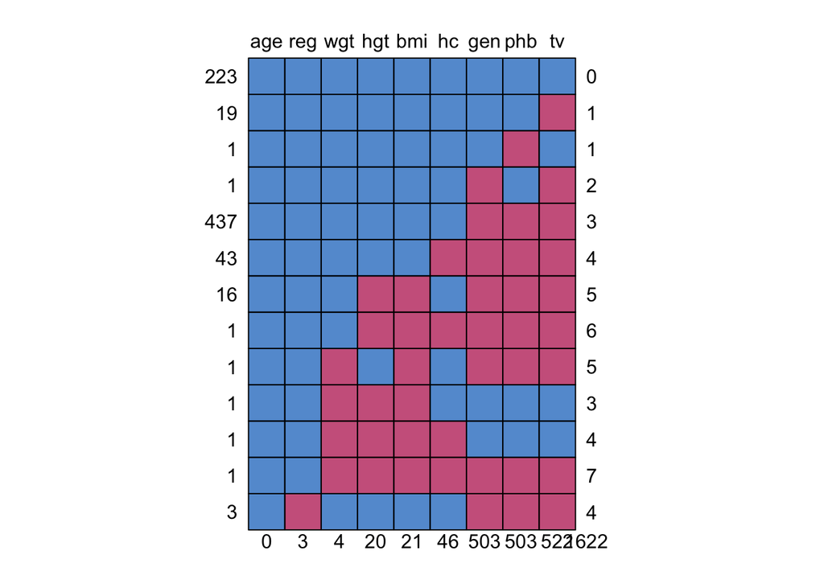

```
##     age reg wgt hgt bmi hc gen phb  tv
## 223   1   1   1   1   1  1   1   1   1    0
## 19    1   1   1   1   1  1   1   1   0    1
## 1     1   1   1   1   1  1   1   0   1    1
## 1     1   1   1   1   1  1   0   1   0    2
## 437   1   1   1   1   1  1   0   0   0    3
## 43    1   1   1   1   1  0   0   0   0    4
## 16    1   1   1   0   0  1   0   0   0    5
## 1     1   1   1   0   0  0   0   0   0    6
## 1     1   1   0   1   0  1   0   0   0    5
## 1     1   1   0   0   0  1   1   1   1    3
## 1     1   1   0   0   0  0   1   1   1    4
## 1     1   1   0   0   0  0   0   0   0    7
## 3     1   0   1   1   1  1   0   0   0    4
##       0   3   4  20  21 46 503 503 522 1622
```

```r
md.pattern(boys)
```

The `md.pattern` shows that there are 223 cases without any missing values, 525 observations with at least one value missing, and that there are 1622 missing values in total in the data, such that 24% of the data is missing.

Also, it becomes clear that the variables `gen` (genital Tanner stage), `phb` (pubic hair) and `tv` (testicular volume) have most missing values.

Now we now that there is a substantial amount of missing information in the `boys` data, we can more closely focus on the missing data patterns. A first step could be to test whether missingness in the variables `gen`, `phb` and `tv` depends on someones age.

**3. Create a missingness indicator for the variables `gen`, `phb` and `tv`.**

**4. Assess whether missingness in the variables `gen`, `phb` and `tv` is related to someones age.**

*Hint:* Use the `group_by()` and `summarize()` functions from the `dplyr` library.

Although such differences can be useful, they rarely tell the complete story about the missingness. A useful strategy to assess missing data patterns is visualization, as figures generally tell more than just plain numbers.

**5. Create a histogram for the variable `age`, faceted by whether or not someone has a missing value on `gen`.**

*Hint:* Use the function `facet_wrap` (see `help(facet_wrap)`) to create two separate histograms for both groups.

Now we know somewhat more about the missingness problem in the `boys` dataset, we can continue visualizing other relationships in the data. The next step is to visualize the relationship between `age` and `bmi`.

**6. Create a scatterplot with `age` on the x-axis and `bmi` on the y-axis, using the function `geom_point()`.**

Although we already know how missingness in the variable `gen` is related to `age`, we do not know whether `gen` is also related to `bmi`.

**7. Add a colour aesthetic to the previous plot using the missingness indicator of the variable `gen`.**

Usually, we would, at this point, handle the missingness problem accordingly. Yet, the scope of this course does not allow for a thorough module on dealing with missing data. If you are interested in this topic, or if you will need it during future (course)work, there are plenty of online resources. The short list of resources displayed below should get you going.

| Description | Author & Title | Link |
| --- | --- | --- |
| Missing data theory | Van Buuren - Flexible Imputation of Missing Data | [Click](https://stefvanbuuren.name/fimd/) |
| Missing data theory (somewhat more technical) | Little & Rubin - Statistical Analysis with Missing Data | [Click](https://onlinelibrary.wiley.com/doi/book/10.1002/9781119013563) |
| Tutorials on dealing with missing data | Vink & Van Buuren | [Click](https://amices.org/) (see `Vignettes`). |

# Visualizing the boys data

In the remainder of this practical, we will ignore the missing data problems, and focus on visualizing (relations in) the data.

**8. Visualize the relationship between `reg` (region) and `age` using a boxplot.**

**9. Create a density plot of age, splitting the densities by `gen` using the `fill` aesthetic.**

**10. Create a diverging bar chart for `hgt` in the `boys` data set, that displays for every `age` year that year’s mean height in deviations from the overall average `hgt`.**

*Hint:* You will have to create a categorical age variable for every year, and center the variable `hgt` such that it reflects that person’s difference from the mean height in the entire data.

# Regression visualization

So far, we have predominantly focused our visualization on variables in the data. We can easily extend this to visualizing models that are constructed from the data. Similarly to looking at visualizations of variables, visualizations of models can help interpreting the results and the fit of the model, by making things obvious that would be obscure when looking at the raw numbers.

For this exercise, we are going to work with the elastic band data sets from the package `DAAG`, providing information on the stretch of a rubber band. For more information on the data, call `help(elastic1)` or `help(elastic2)`.

**11. Load the data `elastic1` and `elastic2` and bind the data frames together using the function `bind_rows()` and add a grouping variable indicating whether an observation comes from `elastic1` or from `elastic2`.**

**12. Create a scatterplot mapping `stretch` on the x-axis and `distance` on the y-axis, and map the just created group indicator as the color aesthetic.**

**13. Recreate the previous plot, but now assess whether the results of the two data sets appear consistent by adding a linear regression line.**

*Hint:* Use the function `geom_smooth()`.

**14. For each of the data sets `elastic1` and `elastic2`, fit a regression model with `y = distance` on `x = stretch` using `lm(y ~ x, data)`.**

**15. For both of the previously created fitted models, determine the fitted values and the standard errors of the fitted values, and the proportion explained variance $R^2$.**

*Hint:* Check out the `predict` function in `R` and notice the `se.fit` argument, as well as the `summary` function.

**16. Study the residual versus leverage plots for both models.**

*Hint:* Use `plot(which = 5)` on the fitted objects.

**17. Use the `elastic2` variable `stretch` to obtain predictions on the model fitted on `elastic1`.**

**18. Now make a scatterplot to investigate similarity between the predicted values and the observed values for `elastic2`.**

# Hand-in

When you have finished the practical,

- enclose all files of the project (i.e. all `.R` and/or `.Rmd` files including the one with your answers, and the `.Rproj` file) in a zip file or folder, and
- hand in that zip or folder by PR from your fork [here](https://github.com/gerkovink/INFOMDA1-2021). Do so before Lecture 4.